# 1. Giới thiệu

## 4.2. PPO có gió

### 4.2.1. 1e6 Timesteps, Batchsize = 64, n_steps = 2048 (Training time: 3h12p)

Actor Loss

Critic Loss

Rewards

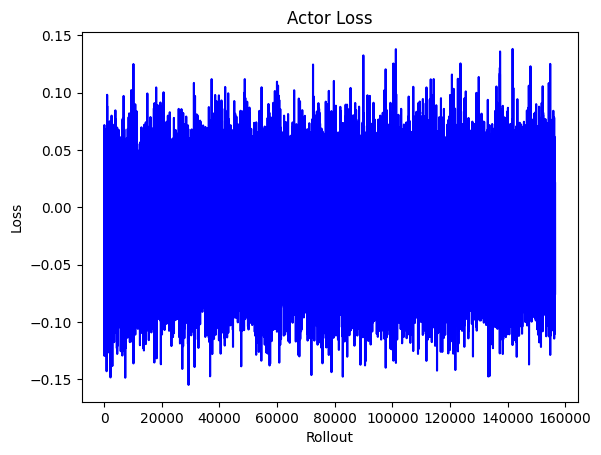

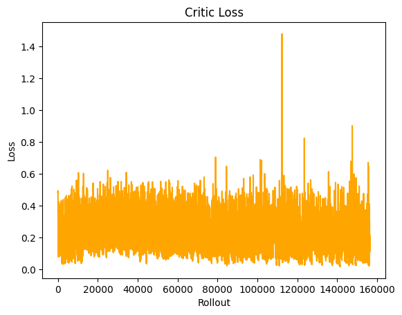

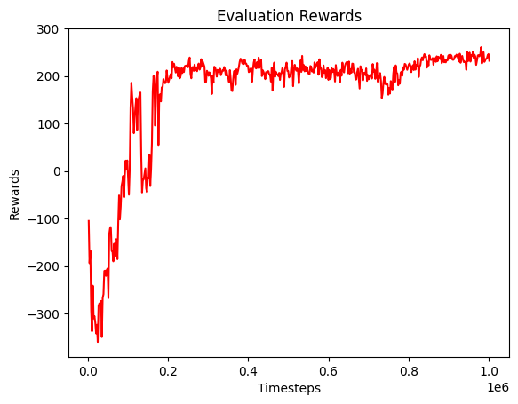

**Standard Deviation**

**Success Rate**

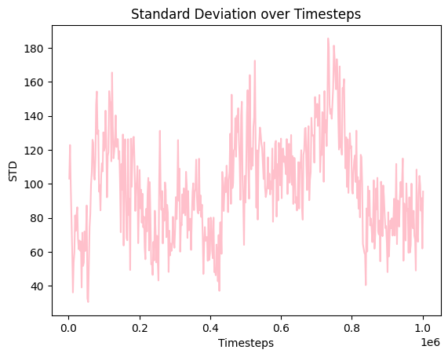

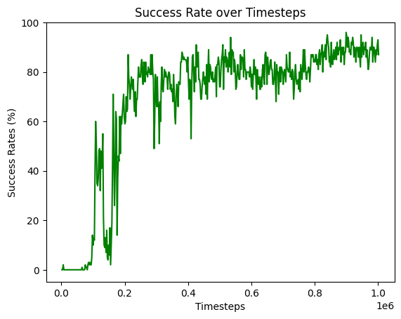

**Best reward collected**: *273.43429085932473*

[video not shown]

### 4.2.2. 1e6 Timesteps, Batchsize = 256, n_steps = 2048 (Training time: 3h20p)

Actor Loss

Critic Loss

Rewards

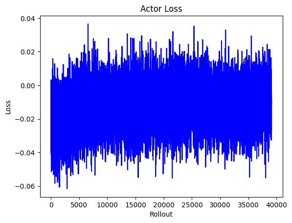

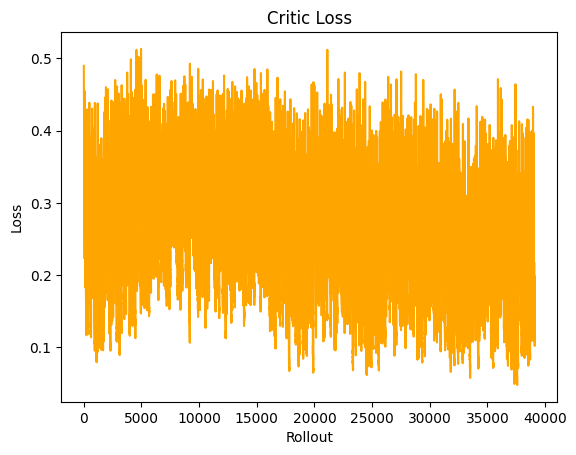

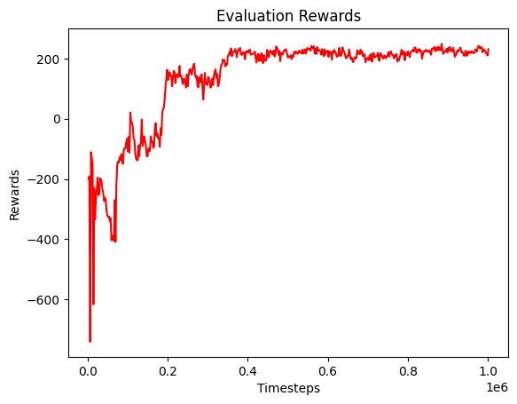

**Standard Deviation**

**Success Rate**

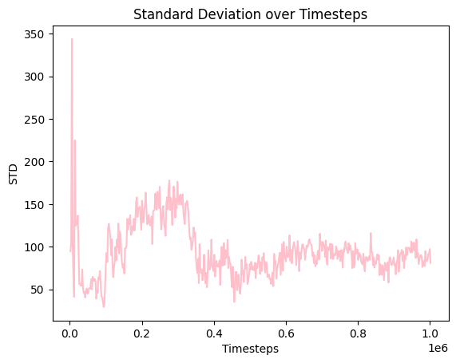

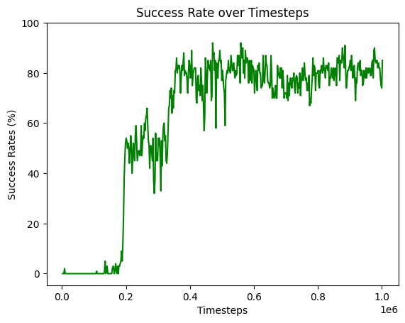

**Best reward collected**: *277.108768843627*

[video not shown]

### 4.2.3. 1e6 Timesteps, Batchsize = 64, n_steps = 4096 (Training time: 2h45p)

Actor Loss

Critic Loss

Rewards

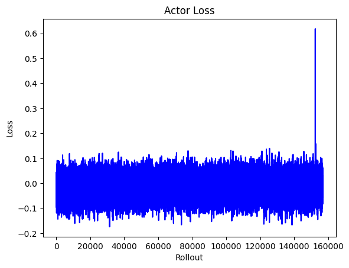

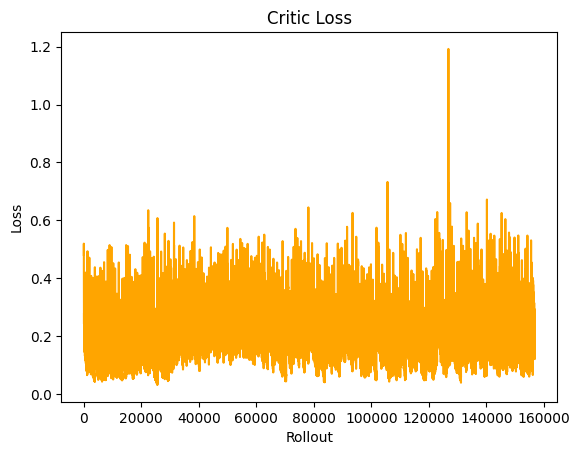

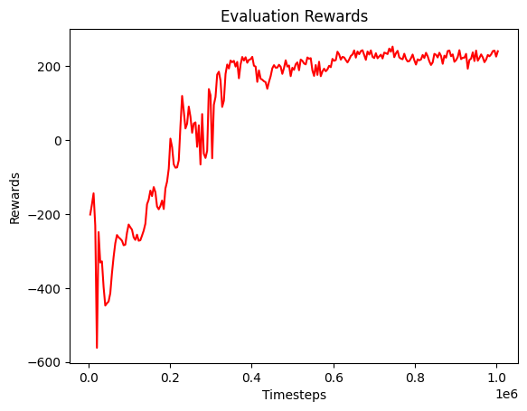

**Standard Deviation**

**Success Rate**

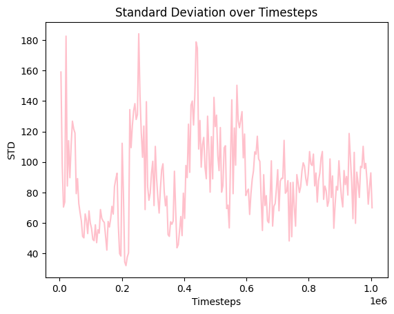

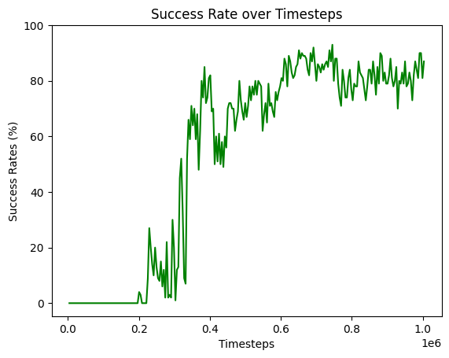

**Best reward collected**: *286.28957209302223*

[video not shown]

### 4.2.4. 1e6 Timesteps, Batchsize = 256, n_steps = 4096 (Training time: 2h40p)

Actor Loss

Critic Loss

Rewards

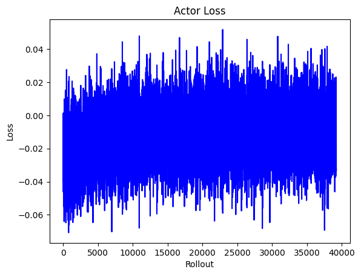

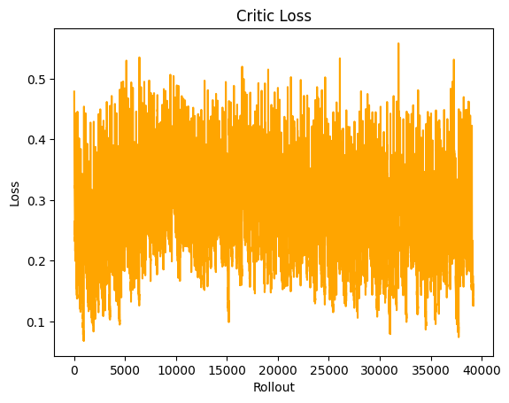

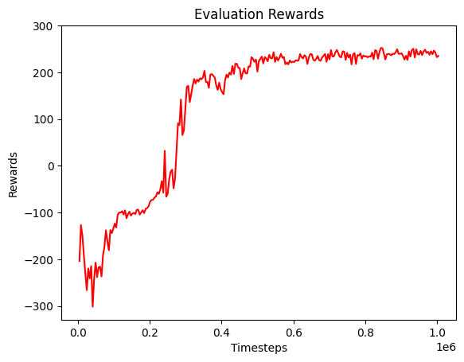

**Standard Deviation**

**Success Rate**

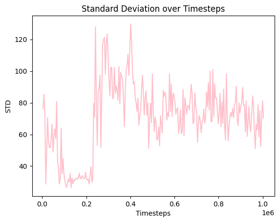

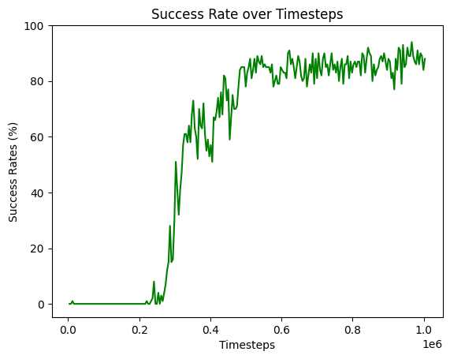

**Best reward collected**: *271.1365183294953*

[video not shown]

# 5. Tổng kết quá trình huấn luyện

Qua kết quả thu được, em nhận thấy rằng việc sử dụng thuật toán Proximal Policy Optimization (PPO) mang lại hiệu quả huấn luyện cao hơn rõ rệt so với Advantage Actor Critic (A2C). Nguyên nhân chính đến từ tính ổn định cao của PPO: thuật toán này giới hạn độ thay đổi giữa các chính sách cũ và mới thông qua hàm phạt (clipping), từ đó tránh được tình trạng cập nhật quá lớn làm hỏng chính sách đang học. Nhờ vậy, quá trình huấn luyện diễn ra trơn tru hơn, ít dao động mạnh, và giúp Agent dễ dàng hội tụ đến chiến lược tối ưu.

Bên cạnh đó, việc lựa chọn và tinh chỉnh các siêu tham số như learning rate, batch size, discount factor, v.v., cũng đóng vai trò rất quan trọng. Với bộ siêu tham số phù hợp, thuật toán PPO đã nhanh chóng đạt được sự hội tụ: Agent không những học được cách chơi mà còn thể hiện được những hành vi thông minh, chủ động đưa ra chiến lược tối ưu trong môi trường.

Ngoài ra, qua quá trình thực nghiệm, em cũng nhận thấy PPO có khả năng khái quát tốt hơn, tức là Agent không chỉ học thuộc một vài tình huống cụ thể mà có thể thích ứng linh hoạt với các trạng thái khác nhau trong môi trường (không có gió, có gió...). Điều này cho thấy tiềm năng lớn của PPO khi áp dụng vào các bài toán phức tạp hơn trong thực tế.

Tuy nhiên, vẫn còn một số hạn chế cần lưu ý, chẳng hạn như thời gian huấn luyện khá lâu do PPO yêu cầu lượng sample lớn hơn để đạt được sự ổn định. Trong tương lai, có thể xem xét các cải tiến như sử dụng kỹ thuật Early Stopping, điều chỉnh siêu tham số, tối ưu thời gian chạy, ....

Nếu đã đọc đến đây, em xin trân trọng cảm ơn thầy vì đã xem qua bài báo cáo trình bày của em. Vì đây là lần đầu tiên huấn luyện mô hình nên trong quá trình viết báo cáo và thực hành huấn luyện có thể có thiếu sót, hoặc có đôi chỗ em chưa nắm vững kiến thức, mong thầy thông cảm và bỏ qua.

Chúc thầy một ngày tốt lành !

# 6. Tài liệu tham khảo

1. Thông tin về môi trường huấn luyện Lunar Lander: [Lunar Lander Gymnasium Documentation](https://gymnasium.farama.org/environments/box2d/lunar_lander/)
2. Kiến thức về Advantage Actor Critic (A2C) cho người mới: [Actor Critic methods with Robotics environments](https://huggingface.co/learn/deep-rl-course/unit6/introduction)
3. Kiến thức về Proximal Policy Optimization (PPO) cho người mới: [Proximal Policy Optimization (PPO)](https://huggingface.co/learn/deep-rl-course/unit6/introduction)
4. Kiến thức về Advantage Actor Critic (A2C) trên trang DataCamp: [Advantage Actor Critic](https://campus.datacamp.com/courses/deep-reinforcement-learning-in-python/introduction-to-policy-gradient-methods?ex=7)
5. Kiến thức về Proximal Policy Optimization (PPO) trên trang DataCamp: [Proximal Policy Optimization](https://projector-video-pdf-converter.datacamp.com/36398/chapter4.pdf)
6. Paper chính thức của A2C: [Asynchronous Methods for Deep Reinforcement Learning](https://arxiv.org/pdf/1602.01783)
7. Paper chính thức của PPO: [Proximal Policy Optimization Algorithms](https://arxiv.org/pdf/1707.06347)
8. Paper chính thức của GAE: [High-Dimensional Continuous Control Using Generalized Advantage Estimation](https://arxiv.org/pdf/1506.02438)
9. Dự án nghiên cứu Thạc sĩ: [Towards Delivering a Coherent Self-Contained Explanation of Proximal Policy Optimization](https://fse.studenttheses.ub.rug.nl/25709/1/mAI_2021_BickD.pdf)